# Homework 7: The one-sample t-test

# NAME: Michael Darfler

# NETID: mbd25

**DUE DATE: November 2, 2019 by 11:59pm**

**For this homework, it will be helpful to have a copy of the knitted version of this document to answer the questions as much of it is written using mathematical notation that may be difficult to read when the document is not knitted.**

## Instructions

For this homework:

1. All calculations must be done within your document in code chunks. Provide all intermediate steps.
2. Include any mathematical formulas you are using for a calculation. Surrounding mathematical expresses by dollar signs makes the math look nicer and lets you use a special syntax (called Latex) that allows for Greek letters, fractions, etc. Note that this is not R code and therefore should not be put in a code chunk (you will get an error if you do). You can put these immediately before the code chunk where you actually do the calculation.
3. To help you solve these problems, you will find it helpful to draw a picture (as in Lab 8). Please do so by hand on paper, but do not worry about submitting this picture. (You will indirectly get credit for having drawn the picture by being more likely to have the right answer!)
4. Be sure you have read Lab 8 carefully before starting this homework.

## Hypothesis Testing for $\mu$ Using a t-distribution

### Review: When can we treat $\bar X_n$ as normal?

As in Lab 8, hypothesis testing for $\mu$ can be based on the distribution of $\bar X_n$. In the lab it was assumed that $\bar X_n \sim N(\mu, \sigma/\sqrt{n})$. Generally, this assumption can be made at least approximately when the $X_i$’s are independent and one of the following conditions holds:

1. The sample size, $n$, is greater than 30 and the distribution isn’t strongly skewed. In that case, the Central Limit Theorem applies. (For the case of sampling from a Bernoulli distribution, we have a more specific rule, namely that $n\hat p$ and $n(1 - \hat p)$ should both be greater than or equal to 10.)
2. The sample, $X_i, i = 1, \dots, n$, is iid from $N(\mu, \sigma)$.

### Doing inference when $\bar X_n \sim N(\mu, \sigma/\sqrt{n})$

If the population standard deviation $\sigma$ is known, we can do tests (and form confidence intervals) based on the fact that, at least approximately,
$$\frac{\bar X_n - \mu}{\sigma/\sqrt{n}} \sim N(0,1).$$
This worked fine in Lab 8 because we were told $\sigma$. But typically we don’t know $\sigma$. This is the *identical* situation as with confidence intervals, so this is a good time for you to review Lecture 13. The idea is to replace $\sigma$ by $S_n$, the standard deviation of the sample.

**If $n$ is sufficiently large**, we expect $S_n$ to be so close to $\sigma$ that we can just assume $\frac{\bar X_n - \mu}{S_n/\sqrt{n}}$ is approximately $N(0,1)$, and we can simply operate as in Lab 8.

**If $n$ is small**, however, we have to account for the variability introduced by replacing $\sigma$ (an unknown but fixed number) by $S_n$ (random since the sample is random), and we will find that
$$\frac{\bar X_n - \mu}{S_n/\sqrt{n}} \text{ is not } N(0,1).$$

Do we know what the distribution of $\frac{\bar X_n - \mu}{S_n/\sqrt{n}}$ is when $n$ is small? The answer, unfortunately, is “no” in general **except for the special case when $X_i, i = 1, \dots, n$, iid from $N(\mu, \sigma)$. Only in this case for any** $n>1$,

$$\frac{\bar X_n - \mu}{S_n/\sqrt{n}}\sim t_{n-1}.$$
That is, this random variable follows a $t$-distribution with $n-1$ degrees of freedom.

We will still consider the three alternative hypotheses presented in Lab 8 and always take $H_0$ to be $\mu=\mu_0$.

### Problem 1

A study was conducted of a simple random sample of 15 adult male patients following a new treatment for congestive heart failure. One of the variables measured on the patients was the increase in exercise capacity (in minutes) over a 4-week treatment period. Assume this variable is normally distributed. The previous treatment regime had produced an average of $\mu =2$ minutes. The researchers wanted to evaluate whether the new treatment had a different impact on the increase in exercise capacity than the old treatment. The data can be found in the *Heart.csv* file.

1. What are the null and alternative hypotheses of this study?

> $H_0: \mu = \mu_0$  
> $H_A: \mu \neq \mu_0$  
> $\mu$ = the increase in exercise capacity after the new treatment  
> $\mu_0 = 2.0$
2. What is the distribution of the standardized sample mean, $\frac{\bar X_n - \mu_0}{S_n/\sqrt{n}}$, under the null hypothesis for this study?

> The distribution of the standardized sample mean under the null hypothesis for this study is $\frac{\bar X_n - \mu}{S_n/\sqrt{n}} \sim t_{14}$.

## Rejection Regions and p-Values Using the t-distribution

Look back at Steps 1 – 4 at the bottom of page 1 of Lab 8. For Step 2, we used that $\bar X_n\sim N(\mu_0,\sigma/\sqrt{n})$ under $H_0$, which is equivalent to
$$\frac{\bar X_n - \mu_0}{\sigma/\sqrt{n}} \sim N(0,1).$$

When $\sigma$ is unknown and when it is valid to use a t-distribution (see above), we replace the above with the fact that
$$\frac{\bar X_n - \mu_0}{S_n/\sqrt{n}}\sim t_{n-1}$$
under $H_0$. Other than that, all the same logic used in Lab 8 applies. Rather than using the quantiles of $N(0,1)$ you use the corresponding quantiles of $t_{n-1}$.

Likewise at the bottom of page 5, Steps 1 – 4 still apply, just Step 2 has a different null distribution.

### Problem 2

1. Using a code chunk, import the data set *Heart.csv* into the workspace of this document (look back at Lab 6 if you need help). Make sure it is read in correctly.

```r
heart <- read.csv("https://raw.githubusercontent.com/mdarfler/BTRY_6010/master/Homework/HW7/Heart(4).csv")
```

2. Assuming the significance level of the test is 0.05, what is the rejection region of the test described in Problem 1?

rejection region is $\frac{|\bar x_n - \mu_0 |}{s/\sqrt(n)} > t_{\alpha/2, n-1}$

```r
alpha <- 0.05
dat <- heart$Increase
mu_0 <- 2.0
n <- length(dat)
s <- sd(dat)
SE <- s/sqrt(n)
quantile <- -qt(alpha/2,n-1)


cutoff = quantile
```

> The rejection region for the test is $\frac{|\bar x_n - \mu_0 |}{s/\sqrt(n)} >$ 2.145
3. Compute the statistic, $\frac{\bar x_n - \mu_0}{s/\sqrt{n}}$, needed to perform this test using the variable `Increase` from the `Heart` data.

```r
mu_0 <- 2.0
dat <- heart$Increase
x_bar <-mean(dat)
n <- length(dat)
s <- sd(dat)
SE <- s/sqrt(n)

test_statistic <- {x_bar-mu_0}/SE
```

> The test statistic $\frac{\bar x_n - \mu_0}{s/\sqrt{n}}$ from the data is 2.22.
4. Based on the rejection region, should we reject $H_0$?

> Since $|\bar x_n - \mu_0| > t_{\alpha/2,n-1} \frac{S}{\sqrt{n}}$ we reject $H_0$

### Problem 3

1. What is the p-value of the test described in Problem 1?

$$P(\bar X_n-\mu_0 > |\bar x_n-\mu_0| \cup \bar X_n-\mu_0 < -|\bar x_n-\mu_0|~|~H_0\text{ true}) = 2P(\bar X_n-\mu_0 > |\bar x_n-\mu_0|~|~H_0\text{ true}).$$

$$\frac{\bar X_n-\mu_0}{\sigma/\sqrt{n}}\sim t_{n-1},$$
$$z_n=\frac{\bar x_n-\mu_0}{s/\sqrt{n}},$$
$$P( t_{n-1} > |z_n| \text{ or } t_{n-1} < -|z_n|) = 2 P(t_{n-1} > |z_n|).$$

```r
p_value <- (1 - pt(test_statistic, n-1))*2
```

> The p-value of the test is 0.043
2. Should we reject $H_0$ at the $0.05$ level based on this p-value?

> We should reject $H_0$ based on this p-value.

## Power calculation for a t-test

When the study described above was being planned, the researchers wanted to make sure that if the new treatment were to lead to a (population-level) $\mu=3$ minute increase in exercise, that the study would be able to reject the null that $\mu=2$ in favor of the alternative $\mu\neq2$. In particular, they wanted to choose a sample size $n$ large enough so that there would be a $90\%$ probability that the study would reject the null hypothesis when $\mu=3$.

They did a Monte Carlo study to decide what sample size would be required. In particular, they simulated data like the kind they expected to collect: $X_1,\ldots, X_n\sim N(\mu, \sigma)$. They took $\mu=3$ since they wanted to know about a probability in the case that $\mu=3$. From the previous literature, they guessed that $\sigma=1$ minute would be a reasonable value. This was a big guess, but they figured it’d be better to have a rough sense of $n$ required than to just pick a sample size completely arbitrarily.

### Problem 4

1. Write a code chunk that does the following two things:
- draws a realization of a sample of size $n$ from the distribution described above (for now, your first line of code can set `n = 10`).
- does exactly what was done in Problem 2 for parts (b)-(d) but on the sample of simulated data instead of on the actual data (don’t forget that the quantile of the t-distribution will change since $n$ is different). For part (d), the necessary comparison should be done using logic operations in R – the output of the code should be `TRUE` if the test rejects $H_0$ in favor of $H_a$ and `FALSE` if the test fails to reject $H_0$.

```r
n = 10
mu0 = 2
muA = 3
sigma = 1
alpha <- 0.05
SE = sigma/sqrt(n)

cutoff <- mu0 + -qt(alpha/2, n-1) * SE

realization <- rnorm(n,muA,sigma)
x_bar <- mean(realization)

x_bar > cutoff
```

```
## [1] TRUE
```

2. To perform a Monte Carlo simulation, we want to repeat (a) a very large number of times (perhaps `nsim = 100000`) and calculate the proportion of times the test rejects. Write a code chunk with a `for` loop that does this. Hint: It may help to look back at past examples of Monte Carlo studies. (Note: It is possible, but more advanced, to write this without a `for` loop. If you’re up for the challenge, you should go for it. But this is not required.)

```r
n = 10
mu0 = 2
muA = 3
sigma = 1
alpha <- 0.05
SE = sigma/sqrt(n)

cutoff <- mu0 + -qt(alpha/2, n-1) * SE

count = 0;
simulations = 100000

for(i in 1:simulations){
  realization <- rnorm(n,muA,sigma)
  x_bar <- mean(realization)
  if(x_bar > cutoff){
    count = count + 1
  }
}

count/simulations
```

```
## [1] 0.81585
```

3. Use the code from part (b) to estimate the power for four values of $n$. Try a wide enough range of $n$ values to see a wide range of powers. Also, include $n=15$ to see what they would have estimated the power of their own study to have been.

```r
n_sim <-  100000
mu0 <-  2
muA <-  3
sigma <-  1
alpha <- 0.05

sample_size <- c(10:15)
power <- rep(0,length(x))

for(i in 1:length(sample_size)){
  n <- sample_size[i]
  SE <- sigma/sqrt(n)
  cutoff <- mu0 + -qt(alpha/2, n-1) * SE

  count <- 0

  for(j in 1:n_sim){
    realization <- rnorm(n,muA,sigma)
    x_bar <- mean(realization)
    if(x_bar > cutoff){
      count = count + 1
    }
  }
  power[i] <- count/n_sim
}
```

> The code above runs on my computer but it won’t knit. `Error in eval(expr, envir, enclos): obejct 'x' not found Calls: <Anonymous> ...`  
> `handle -> withCallingHandlers -> withVisible -> eval -> eval Execution halted`  
> Below is the plot of the results

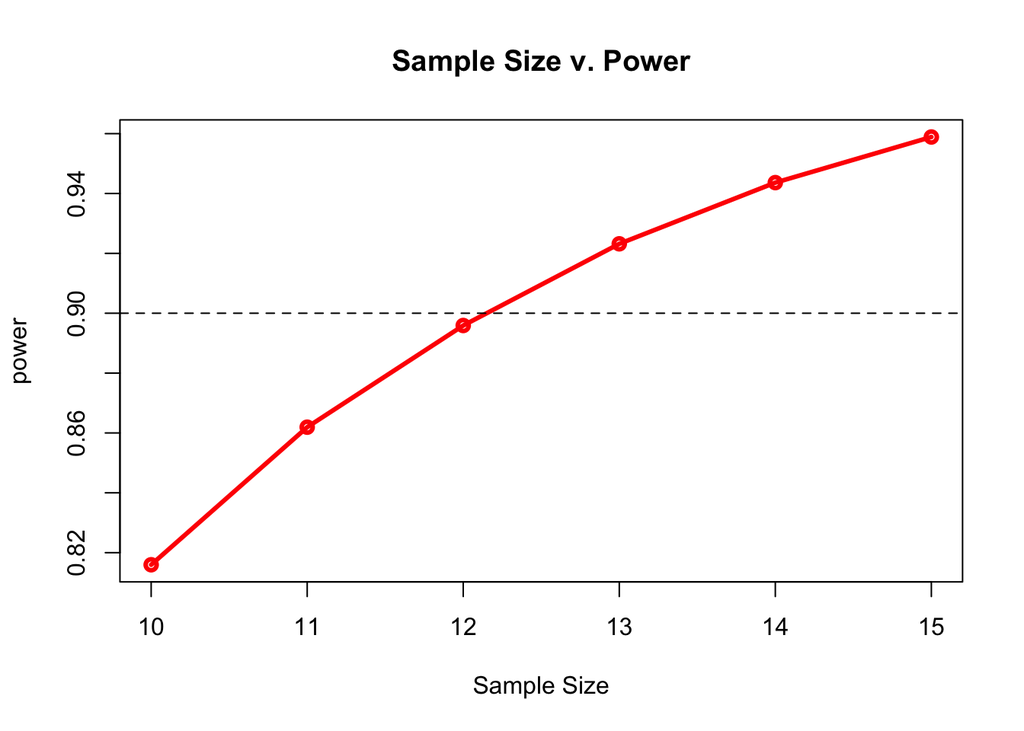

```r
sample_size <- c(10:15)
power <- c(0.81596, 0.86193, 0.89590, 0.92319, 0.94364, 0.95888)
plot(sample_size,power,
     type ="o", col = "red", lwd = "3",
     main = "Sample Size v. Power", xlab = "Sample Size")
abline(h = 0.9, lty = 2)
```

4. Find a value of $n$ (using trial-and-error) for which the power is close to the desired $90\%$.

> You would need a sample size of 13 in order to get a power of over 90%